# LGCPs - An example in one dimension

David Borchers and Finn Lindgren (With study notes from JM)

Generated on 2022-05-27

# Introduction

In this vignette we are going to see how to fit an SPDE to one-dimensional *point* data, i.e. data that consist of the points at which things are located, not the number of points in some area. This is essentially the outcome of a Poisson process in one dimension.

# Setting things up

Load libraries

```r
library(inlabru)
library(INLA)
library(mgcv)
library(ggplot2)
```

# Get the data

```r
data(Poisson2_1D)
```

Take a look at the point (and frequency) data

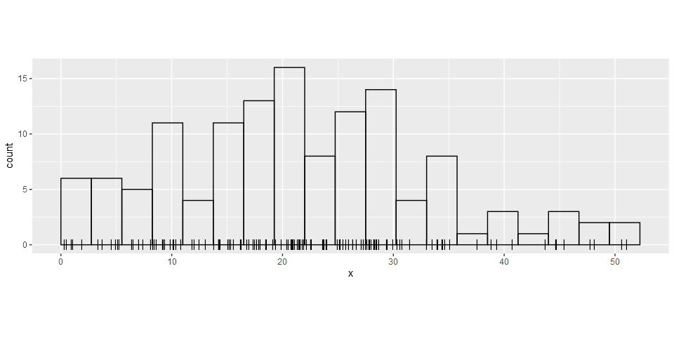

```r
ggplot(pts2) +
  geom_histogram(aes(x = x), binwidth = 55 / 20, boundary = 0, fill = NA, color = "black") +
  geom_point(aes(x), y = 0, pch = "|", cex = 4) +
  coord_fixed(ratio = 1)
```

# Fiting the model

This proceeds in four stages:

1. Define the mesh (essentially the set of locations where knots are to be placed).
2. Define SPDE part of model on the mesh (indicates the autocorrelation structure).
3. Define model formula, including the SPDE object
4. Fit the model to the data

## Stage 1: Build a 1D mesh

```r
x <- seq(0, 55, length.out = 50)
mesh1D <- inla.mesh.1d(loc=x, boundary = "free")
```

The locations `loc` of the knots and the type of `boundary` condition to be implemented. The boundary is optional, but if necessary could be specified in several different ways (and it can even be different at the two extremes of the mesh).

## Stage 2: Make a 1D SPDE model

```r
matern <- inla.spde2.pcmatern(mesh1D, prior.range = c(150, 0.75), prior.sigma = c(0.1, 0.75))
```

The generic function `inla.spde2.generic` creates an `inla.spde2` object, describing the internal structure of an `spde2` model. The `pcmatern` version of this employs a Matern model with a PC prior for the parameters. The Matern model expresses the covariance between two points as a decreasing function of their distance. The two parameters `range` and `sigma` are assigned priors in the typical INLA fashion. For example, the prior for a parameter $\theta$ is given by `c(theta0,Ptheta)`=$(\theta_0,P_\theta)$, such that $P(\theta<\theta_0)=P_\theta$.

## Stage 3: Define model formula, including intercept

```r
mdl <- x ~ spde1D(x, model = matern) + Intercept(1)
```

Note that this is just an assignment to the name `mdl` of a model formula, where the autocorrelation in the variable x is captured solely by the one-dimensional spde model. Presumably, the previously defined model `matern` could be used for modelling the autocorrelation in a variable other than `x`.

*Q:* Would any fixed effects enter the formula here?

## Stage 4: Fit the model

Here, we want to fit to the actual points, and the `inlabru` function that does this is called `lgcp` (for ‘Log Gaussian Cox Process’). The `ips` and `domain` parameters are optional, one or the other can be used. Here are two ways of doing the same thing:

```r
fit.spde <- lgcp(mdl, pts2, ips = ipoints(c(0, 55), 50, name = "x"))
fita.spde <- lgcp(mdl, pts2, domain = list(x = mesh1D))
```

*Q:* If multiple domains needed to be defined, would the second of those options be the only viable approach?

# SPDE parameters

We can look at the posterior distributions of the parameters of the SPDE using the function `spde.posterior`. It returns `x` and `y` values for a plot of the posterior PDF in a data frame, which can be printed using the `plot` function. To see the PDF for the range parameter, for example:

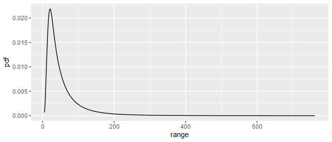

```r
post.range <- spde.posterior(fit.spde, name = "spde1D", what = "range")
plot(post.range)
```

Look at the help file for `spde.posterior` and then plot the posterior for the log of the SPDE range parameter, the SPDE variance and/or log of the variance, and for the Matern covariance function. Make sure you understand the difference between what is plotted for the range and variance parameters, and for the covariance function (which involves both these parameters). Note that the definition of the Matern covariance is

$$C_{\nu}(d)=\sigma^2\frac{2^{\nu-1}}{\Gamma(\nu)}
\left( \sqrt{2\nu}\frac{d}{\rho}\right)^\nu K_\nu \left(
\sqrt{2\nu}\frac{d}{\rho}\right)$$

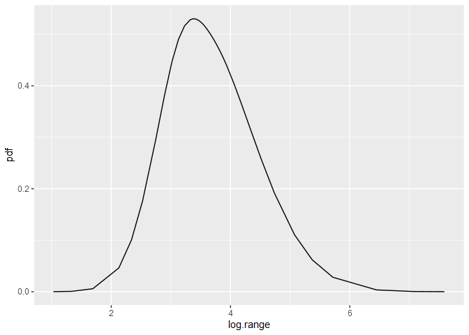

```r
post.log.range <- spde.posterior(fit.spde, name = "spde1D", what = "log.range")
plot(post.log.range) # SOLUTION
```

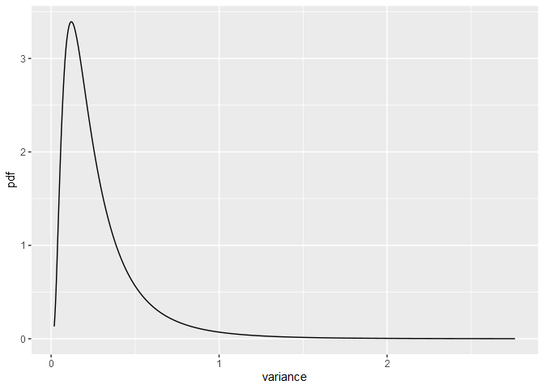

```r
post.variance <- spde.posterior(fit.spde, name = "spde1D", what = "variance")
plot(post.variance) # SOLUTION
```

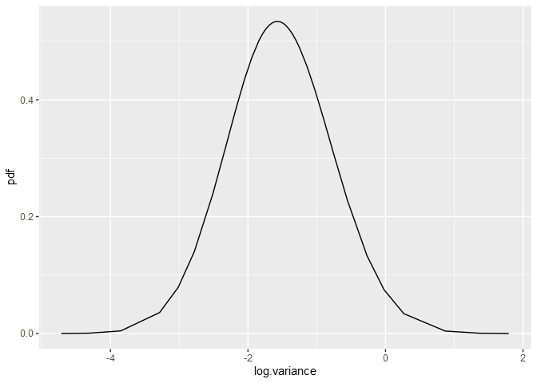

```r
post.log.variance <- spde.posterior(fit.spde, name = "spde1D", what = "log.variance")
plot(post.log.variance) # SOLUTION
```

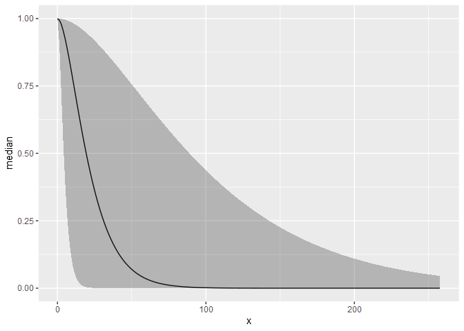

```r
post.matcorr <- spde.posterior(fit.spde, name = "spde1D", what = "matern.correlation")
plot(post.matcorr) # SOLUTION
```

You can get a feel for sensitivity to priors by specifying different priors and looking at the posterior plots.

# Predicting intensity

We can also now predict on any scale we want. For example, to predict on the ‘response’ scale (i.e. the intensity function $\lambda(s)$), we call `predict` thus:

```r
predf <- data.frame(x = seq(0, 55, by = 1)) # Set up a data frame of explanatory values at which to predict
pred_spde <- predict(fit.spde, predf, ~ exp(spde1D + Intercept))
```

while to predict on the linear predictor scale (i.e. that of the log intensity, $\log(\lambda(s))$), we call `predict` thus:

```r
pred_spde_lp <- predict(fit.spde, predf, ~ spde1D + Intercept)
```

here’s how to plot the prediction and 95% credible interval:

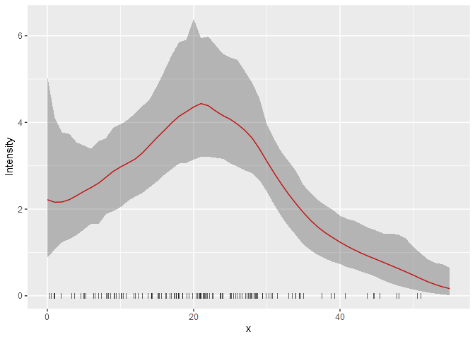

```r
plot(pred_spde, color = "red") +
  geom_point(data = pts2, aes(x = x), y = 0, pch = "|", cex = 2) +
  xlab("x") + ylab("Intensity")
```

How does this compare with the underlying intensity function that generated the data? The function `lambda2_1D( )` in the dataset `Poisson2_1D` calculates the true intensity that was used in simulating these data. In order to plot this, we make a data frame with `x`- and `y`-coordinates giving the true intensity function, $\lambda(s)$. We use lots of `x`-values to get a nice smooth plot (150 values).

```r
xs <- seq(0, 55, length = 150)
true.lambda <- data.frame(x = xs, y = lambda2_1D(xs))
```

Plot the fitted and true intensity functions:

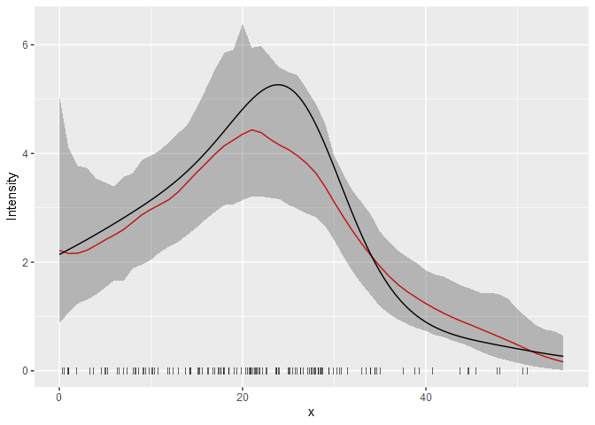

```r
plot(pred_spde, color = "red") +
  geom_point(data = pts2, aes(x = x), y = 0, pch = "|", cex = 2) +
  geom_line(data = true.lambda, aes(x, y)) +
  xlab("x") + ylab("Intensity")
```

# Goodness-of-Fit

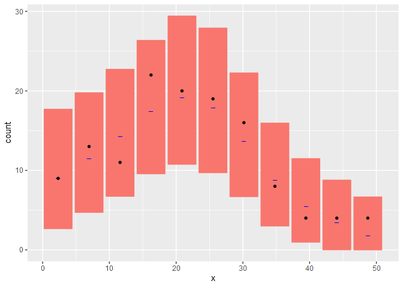

```r
bc <- bincount(
  result = fit.spde,
  observations = pts2,
  breaks = seq(0, max(pts2), length = 12),
  predictor = x ~ exp(spde1D + Intercept)
)

attributes(bc)$ggp
```

# Estimating Abundance

Abundance is the integral of the intensity over space. We estimate it by integrating the predicted intensity over `x`. Integration is done by adding up the intensity at locations `x` weighted by a particular weight. The locations `x` and their weights are constructed using the `ipoints` function (see also use if this function as an option for defining the integration points in the `fit.spde` step)

```r
ips <- ipoints(c(0, 55), 100, name = "x")
head(ips)
```

```
#>       x weight
#> 1 0.275   0.55
#> 2 0.825   0.55
#> 3 1.375   0.55
#> 4 1.925   0.55
#> 5 2.475   0.55
#> 6 3.025   0.55
```

```r
Lambda <- predict(fit.spde, ips, ~ sum(weight * exp(spde1D + Intercept)))
```

This approximates the integral over space as a sum of finite areas, using regularly-spaced integration points. Presumably, we could define irregularly spaced integration points via the function `ipoints`. You can look at the abundance estimate by typing

```r
Lambda
```

```
#>       mean       sd   q0.025   median   q0.975     smin     smax         cv      var
#> 1 129.8393 12.00306 109.7047 128.2675 153.8193 103.7467 155.7596 0.09244546 144.0734
```

But it is not quite that simple! The above posterior for abundance takes account only of the variance due to us not knowing the parameters of the intensity function. It neglects the variance in the number of point locations, given the intensity function. In other words, the uncertainty in the abundance estimate represents the “confidence interval”, not the “prediction interval” in the fitted model. To include this we need to modify `predict( )` as follows:

```r
Nest <- predict(
  fit.spde, ips,
  ~ data.frame(
    N = 50:250,
    dpois = dpois(50:250,
      lambda = sum(weight * exp(spde1D + Intercept))
    )
  )
)
```

This calculates the same statistics as were calculated for `Lambda`, but for every value of `N` from 50 to 250, rather than for the posterior mean `N` alone:

```r
head(Nest)
```

```
#>    N         mean           sd       q0.025       median       q0.975         smin         smax
#> 1 50 2.662149e-10 2.642464e-09 8.561847e-22 7.743430e-16 3.767524e-11 4.331999e-23 2.642648e-08
#> 2 51 5.143865e-10 5.100798e-09 2.529329e-21 1.966207e-15 8.189255e-11 1.318931e-22 5.101196e-08
#> 3 52 9.749247e-10 9.656807e-09 7.328572e-21 4.896572e-15 1.745888e-10 3.938424e-22 9.657653e-08
#> 4 53 1.813199e-09 1.793725e-08 2.083387e-20 1.196417e-14 3.652014e-10 1.153853e-21 1.793902e-07
#> 5 54 3.310370e-09 3.270092e-08 5.813157e-20 2.869166e-14 7.498038e-10 3.317878e-21 3.270452e-07
#> 6 55 5.935036e-09 5.853215e-08 1.592555e-19 6.755536e-14 1.511509e-09 9.367021e-21 5.853937e-07
#>         cv          var
#> 1 9.926058 6.982618e-18
#> 2 9.916276 2.601814e-17
#> 3 9.905183 9.325393e-17
#> 4 9.892601 3.217451e-16
#> 5 9.878328 1.069350e-15
#> 6 9.862138 3.426012e-15
```

We compute the 95% prediction interval and the median as follows

```r
inla.qmarginal(c(0.025, 0.5, 0.975), marginal = list(x = Nest$N, y = Nest$mean))
```

```
#> [1] 100.1118 129.2290 162.0738
```

Compare `Lambda` to `Nest` by plotting: First calculate the posterior conditional on the mean of `Lambda`

```r
Nest$plugin_estimate <- dpois(Nest$N, lambda = Lambda$mean)
```

Then plot it and the unconditional posterior

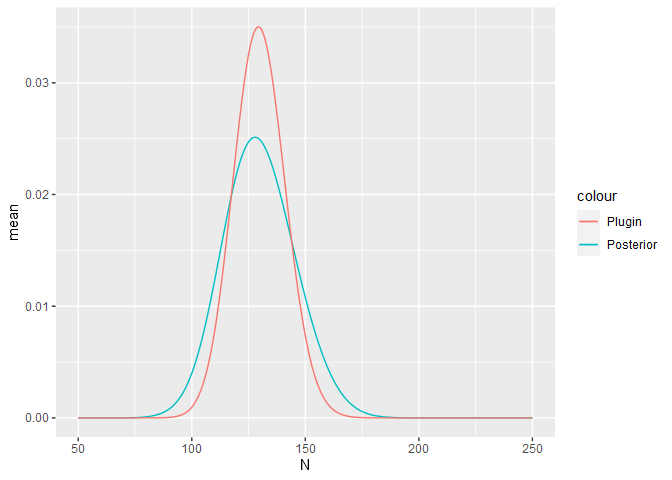

```r
ggplot(data = Nest) +
  geom_line(aes(x = N, y = mean, colour = "Posterior")) +
  geom_line(aes(x = N, y = plugin_estimate, colour = "Plugin"))
```

Do the differences make sense to you?

# Comparison to GAM fit

Now refit a GAM for the count data of `Poisson2_1D` and plot the estimated intensity function from this GAM fit, together with the LGCP fitted above and the true intensity.

```r
cd2 <- countdata2
fit2.gam <- gam(count ~ s(x, k = 10) + offset(log(exposure)), family = poisson(), data = cd2)
dat4pred <- data.frame(x = seq(0, 55, length = 100), exposure = rep(cd2$exposure[1], 100))
pred2.gam <- predict(fit2.gam, newdata = dat4pred, type = "response")
dat4pred2 <- cbind(dat4pred, gam = pred2.gam) # SOLUTION
```

You should get a plot like this (thick line is the true intensity, the thin solid line the inlabru fit, the dashed line the GAM fit:

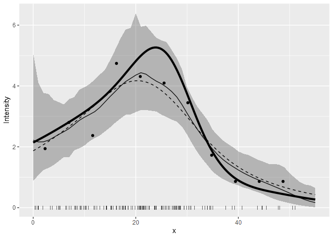

```r
plot(pred_spde) +
  geom_point(data = pts2, aes(x = x), y = 0, pch = "|", cex = 2) +
  geom_line(data = dat4pred2, aes(x, gam / exposure), lty = 2) +
  geom_line(data = true.lambda, aes(x, y), lwd = 1.5) +
  geom_point(data = cd2, aes(x, y = count / exposure)) +
  ylab("Intensity") + xlab("x") # SOLUTION
```